# Zaliczenie przedmiotu ‘Analiza danych w R’

Studia podyplomowe: ‘Metody Statystycznej Analizy Danych - edycja IX’

Jędrzej Szelc

2024-04-09

## Zestaw zadań 1

### Zestaw 1 - Zadanie numer 4

Oryginalna treść zadania:

*“Stworzyc ramke danych o nazwie osoby, ktora sklada sie z siedmiu obserwacji i dwoch zmiennych: wzrost i waga. Uzupelnic ja danymi wg wlasnego uznania (ale racjonalnie!). Nastepnie, z wykorzystaniem funkcji: str(), ktora pozwala na poznanie struktury obiektu, head(), ktora pozwala na poznanie kilku pierwszych obiektow w zbiorze, tail(), ktora pozwala na poznanie kilku ostatnich obiektow w zbiorze, dim(), ktora pozwala na poznanie wymiaru rozwazanego obiektu, oraz summary() ktora pozwala na wyznaczenie statystyk opisowych w obiekcie, przeprowadzic podstawowa inspekcje danych.”*

Rozwiązanie zadania:

```r
### Import modułów, bibliotek oraz konfiguracja
library(tibble)

### Wektory do ramki danych
wektor_wzrost <- c(182, 168, 174, 193, 181, 177, 167)
wektor_waga <- c(87, 63, 71, 97, 87, 92, 78)

### Tworzenie ramki danych
ramka_danych_osoby <- data.frame(Wzrost = wektor_wzrost,
                                 Waga = wektor_waga)

### Podstawowe inspekcje danych z wykorzystaniem funkcji:
# str()
str(ramka_danych_osoby)
```

```
## 'data.frame':    7 obs. of  2 variables:
##  $ Wzrost: num  182 168 174 193 181 177 167
##  $ Waga  : num  87 63 71 97 87 92 78
```

```r
# head(,3)
head(ramka_danych_osoby, 3)
```

```
##   Wzrost Waga
## 1    182   87
## 2    168   63
## 3    174   71
```

```r
# tail(,3)
tail(ramka_danych_osoby, 3)
```

```
##   Wzrost Waga
## 5    181   87
## 6    177   92
## 7    167   78
```

```r
# dim()
dim(ramka_danych_osoby)
```

```
## [1] 7 2
```

```r
# summary()
summary(ramka_danych_osoby)
```

```
##      Wzrost           Waga
##  Min.   :167.0   Min.   :63.00
##  1st Qu.:171.0   1st Qu.:74.50
##  Median :177.0   Median :87.00
##  Mean   :177.4   Mean   :82.14
##  3rd Qu.:181.5   3rd Qu.:89.50
##  Max.   :193.0   Max.   :97.00
```

### Zestaw 1 - Zadanie numer 5

Oryginalna treść zadania:

*“Wykorzystaj funkcje rownames() do nadania imion obiektom w ramce osoby.”*

Rozwiązanie zadania:

```r
rownames(ramka_danych_osoby) <- c("Jędrzej",
                                  "Katarzyna",
                                  "Anna",
                                  "Bogdan",
                                  "Wiesław",
                                  "Jan",
                                  "Piotr")
ramka_danych_osoby
```

```
##           Wzrost Waga
## Jędrzej      182   87
## Katarzyna    168   63
## Anna         174   71
## Bogdan       193   97
## Wiesław      181   87
## Jan          177   92
## Piotr        167   78
```

### Zestaw 1 - Zadanie numer 6

Oryginalna treść zadania:

*“Stworzyc obiekt BMI, ktory bedzie przechowywal informacje o wartosciach BMI (ang. body mass index) Wyswietl tylko te osoby, ktorych BMI przyjmuje wartosc wieksza niz 30. Ile jest osob o BMI≤25”*

*“Uwaga: Wzor, w jaki wyznacza sie BMI, znajdziesz w sieci. Pomysl, jak do rozwiazania zadania wykorzystac funkcje sum() oraz instrukcje warunkowe?”*

Rozwiązanie zadania:

```r
ramka_danych_osoby <- transform(ramka_danych_osoby,
                                BMI = round(Waga/(Wzrost/100)^2,2))
ramka_danych_osoby
```

```
##           Wzrost Waga   BMI
## Jędrzej      182   87 26.26
## Katarzyna    168   63 22.32
## Anna         174   71 23.45
## Bogdan       193   97 26.04
## Wiesław      181   87 26.56
## Jan          177   92 29.37
## Piotr        167   78 27.97
```

### Zestaw 1 - Zadanie numer 7

Oryginalna treść zadania:

*“W pakiecie datasets znajduje sie wiele ciekawych zbiorow danych, a w szczegolnosci ramki danych mtcars i Orange.”*

Wstępna konfiguracja:

```r
### Import modułów, bibliotek oraz konfiguracja
library(datasets)
library(dplyr)
library(ggplot2)
library(tidyr)
library(tidyverse)
```

#### Zestaw 1 - Podpunkt 7.a

Oryginalna treść podpunktu:

*“Wykorzystaj komendy str() oraz help(), by dowiedziec sie wiecej o tych zbiorach danych. Napisz w kilku slowach, co opisuja w/w pliki z danymi.”*

Rozwiązanie podpunktu:

Funkcja ‘str()’ umożliwia wyświetlenia podsumowania dot. struktury danego obiektu w języku, [1]. W ślad za [1], funkcja ‘str()’ nadaje się najlepiej do analiz wszelkiego rodzaju struktur danych. Funkcja ‘str()’ różni się od ‘summary()’ tym, że ‘str()’ zwraca skrótowe podsumowanie, [1].

Funkcja ‘help()’, podobnie jak operator ‘?’ umożliwiają w Języku R dostęp do dokumentacji technicznej danej funkcji, datasety lub obiektu, [2]. W przypadku korzystania z IDE R-Studio, wywołanie funkcji ‘help()’ lub operatora ‘?’ skutkuje wyświetleniem dokumentacji w oknie pomocy R-Studio.

```r
str(mtcars)
```

```
## 'data.frame':    32 obs. of  11 variables:
##  $ mpg : num  21 21 22.8 21.4 18.7 18.1 14.3 24.4 22.8 19.2 ...
##  $ cyl : num  6 6 4 6 8 6 8 4 4 6 ...
##  $ disp: num  160 160 108 258 360 ...
##  $ hp  : num  110 110 93 110 175 105 245 62 95 123 ...
##  $ drat: num  3.9 3.9 3.85 3.08 3.15 2.76 3.21 3.69 3.92 3.92 ...
##  $ wt  : num  2.62 2.88 2.32 3.21 3.44 ...
##  $ qsec: num  16.5 17 18.6 19.4 17 ...
##  $ vs  : num  0 0 1 1 0 1 0 1 1 1 ...
##  $ am  : num  1 1 1 0 0 0 0 0 0 0 ...
##  $ gear: num  4 4 4 3 3 3 3 4 4 4 ...
##  $ carb: num  4 4 1 1 2 1 4 2 2 4 ...
```

Po użyciu zbioru danych ‘mtcars’ jako argumentu wejściowego funkcji ‘str()’, stwierdzam, że ‘mtcars’ to ramka danych o 11 kolumnach (zmiennych/variables) o długości 32 rekordów każda. Wszystkie kolumny są typu numerycznego (numerical), a co za tym idzie, dane w tych kolumnach są również typu numerycznego. Powyższe informacje są zgodne z dokumentacją techniczną ww. zbioru danych, [3].

```r
help(mtcars)
```

Po użyciu zbioru danych ‘mtcars’ jako argumentu wejściowego funkcji ‘help()’, otrzymałem w oknie ‘Help’ środowiska R-Studio szczegółową dokumentację techniczną ww. zbioru danych. W dokumentacji widzę m.in. opis zbioru danych, wskazówki dot. jego struktury (formatu), pochodzenie danych zawartych w ww. zbiorze oraz przykłady jego zastosowania.

```r
str(Orange)
```

```
## Classes 'nfnGroupedData', 'nfGroupedData', 'groupedData' and 'data.frame':   35 obs. of  3 variables:
##  $ Tree         : Ord.factor w/ 5 levels "3"<"1"<"5"<"2"<..: 2 2 2 2 2 2 2 4 4 4 ...
##  $ age          : num  118 484 664 1004 1231 ...
##  $ circumference: num  30 58 87 115 120 142 145 33 69 111 ...
##  - attr(*, "formula")=Class 'formula'  language circumference ~ age | Tree
##   .. ..- attr(*, ".Environment")=<environment: R_EmptyEnv>
##  - attr(*, "labels")=List of 2
##   ..$ x: chr "Time since December 31, 1968"
##   ..$ y: chr "Trunk circumference"
##  - attr(*, "units")=List of 2
##   ..$ x: chr "(days)"
##   ..$ y: chr "(mm)"
```

Klasa ‘Orange’ jest struktury wektora: c(‘nfnGroupedData’, ‘nfGroupedData’, ‘groupedData’, ‘data.frame’), który zawiera wspomniane kolumny z danymi (rekordami). Wygląda na to, że ‘Orange’ to rodzaj specjalizowanej klasy danych. Kolumna ‘Tree’ to uporządkowany ‘factor’. Powyższe informacje są zgodne z dokumentacją techniczną ww. klasy, [4].

```r
help(Orange)
```

Po użyciu zbioru danych ‘Orange’ jako argumentu wejściowego funkcji ‘help()’, otrzymałem w oknie ‘Help’ środowiska R-Studio szczegółową dokumentację techniczną ww. klasy danych. W dokumentacji widzę m.in. opis klasy danych, wskazówki dot. jej struktury (formatu), pochodzenie danych zawartych w ww. klasie oraz przykłady jej zastosowania.

#### Zestaw 1 - Podpunkt 7.b

Oryginalna treść podpunktu:

*“Wykorzystujac instrukcje warunkowe, wyswietl wylacznie auta posiadajace 6 cylindrow.”*

Rozwiązanie podpunktu:

Korzystam z bilbioteki ‘dyplr’, która umożliwia wygodne przetwarzanie danych, w tym m.in. ramek danych.

```r
mtcars %>%
  filter(cyl == 6)
```

```
##                 mpg cyl  disp  hp drat    wt  qsec vs am gear carb
## Mazda RX4      21.0   6 160.0 110 3.90 2.620 16.46  0  1    4    4
## Mazda RX4 Wag  21.0   6 160.0 110 3.90 2.875 17.02  0  1    4    4
## Hornet 4 Drive 21.4   6 258.0 110 3.08 3.215 19.44  1  0    3    1
## Valiant        18.1   6 225.0 105 2.76 3.460 20.22  1  0    3    1
## Merc 280       19.2   6 167.6 123 3.92 3.440 18.30  1  0    4    4
## Merc 280C      17.8   6 167.6 123 3.92 3.440 18.90  1  0    4    4
## Ferrari Dino   19.7   6 145.0 175 3.62 2.770 15.50  0  1    5    6
```

#### Zestaw 1 - Podpunkt 7.c

Oryginalna treść podpunktu:

*“Jaka przecietna liczbe koni mechanicznych (zmienna hp) posiadaja auta o spalaniu (zmienna mpg) mniejszym niz 20.”*

Rozwiązanie podpunktu:

Pod słowem ‘przeciętne’ rozumiem ‘średnie’ w znaczeniu średniej arytmetycznej. Jako ‘mniejsze niż’ rozumiem ‘mniejsze-nie-równe’, czyli wykorzystam operator ‘<’.

```r
srednie_spalanie_zaokraglone <- round(mtcars %>%
  filter(mpg < 20) %>%
  pull(hp) %>%
  mean(),1)
srednie_spalanie_zaokraglone
```

```
## [1] 191.9
```

#### Zestaw 1 - Podpunkt 7.d

Oryginalna treść podpunktu:

*“Narysuj histogram (formula hist()), dla wybranej zmiennej w zestawie danych Orange.”*

Rozwiązanie podpunktu:

Korzystam z bilbioteki ‘ggplot2’, która umożliwia wygodną wizualizację danych.

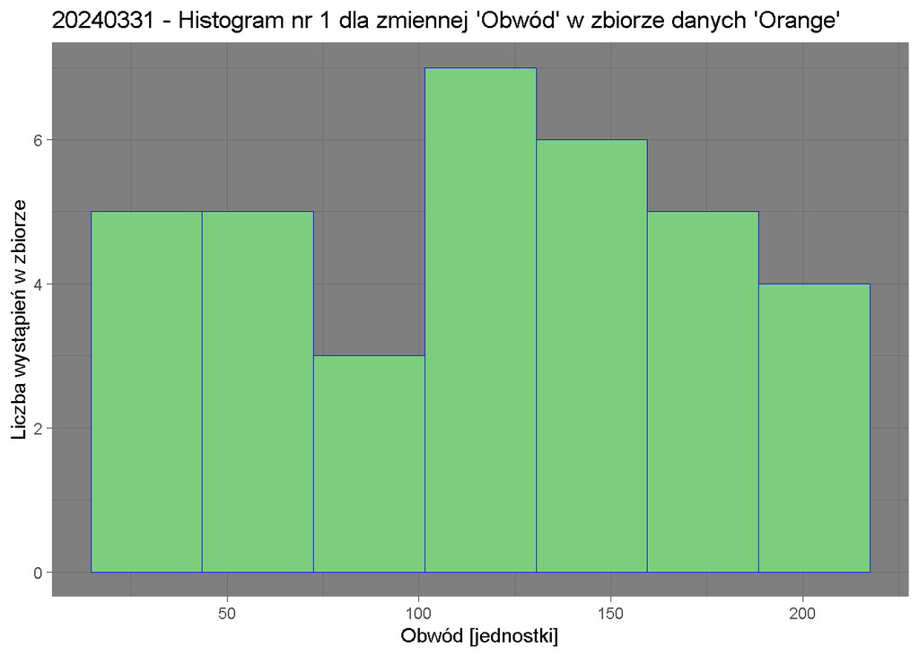

```r
# Automatyczna szerokość 'bins' histogramów
liczba_obserwacji_w_kolumnach <- nrow(Orange)
wspolczynnik_normalizacji_szerokosci_bin <- 1.2
szerokosc_bin_do_wszystkich_histogramow <-
  round(liczba_obserwacji_w_kolumnach/wspolczynnik_normalizacji_szerokosci_bin,0)

# Pierwszy histogram
Orange %>%
  ggplot() +
  geom_histogram(aes(x = circumference),
                 binwidth = szerokosc_bin_do_wszystkich_histogramow,
                 fill = "palegreen3", colour = "blue", linewidth = 0.1) +
  theme_dark() +
  labs(title = "20240331 - Histogram nr 1 dla zmiennej 'Obwód' w zbiorze danych 'Orange'",
       subtitlte = "Podtytuł dla Orange - 1",
       x = "Obwód [jednostki]", y = "Liczba wystąpień w zbiorze")
```

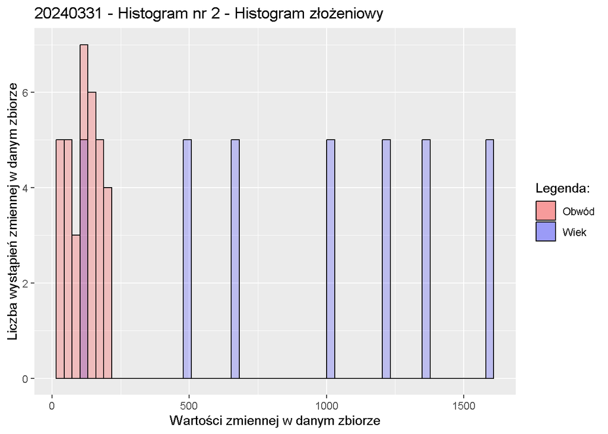

```r
# Drugi histogram - Histogram złożeniowy
ggplot(Orange) +
  geom_histogram(aes(x = age, fill = "Wiek"),
                 binwidth = szerokosc_bin_do_wszystkich_histogramow,
                 alpha = 0.2, colour = "black") +
  geom_histogram(aes(x = circumference, fill = "Obwód"),
                 binwidth = szerokosc_bin_do_wszystkich_histogramow,
                 alpha = 0.2, colour = "black") +
  scale_fill_manual(values = c("red","blue")) +
  labs(title = "20240331 - Histogram nr 2 - Histogram złożeniowy",
     subtitlte = "Podtytuł dla Orange - 2",
     x = "Wartości zmiennej w danym zbiorze",
     y = "Liczba wystąpień zmiennej w danym zbiorze",
     fill = "Legenda:")
```

#### Zestaw 1 - Podpunkt 7.e

Oryginalna treść podpunktu:

*“Narysuj wykres pudelkowy z wasem (boxplot()) dla zmiennych mpg, hp i qsec ze zbioru mtcars.”*

Rozwiązanie podpunktu:

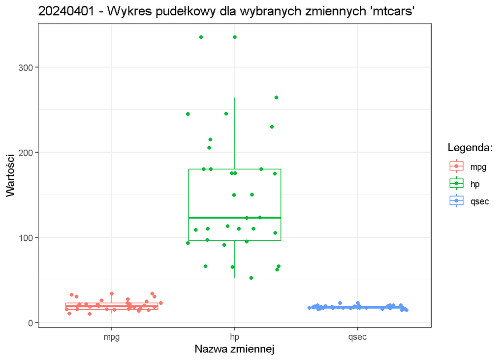

```r
# Wykres pudełkowy dla trzech zmiennych
okrojona_ramka <- mtcars %>%
  select(mpg, hp, qsec)
ggplot(stack(okrojona_ramka), aes(x = ind, y = values, col = ind)) +
  geom_boxplot() +
  theme_bw() +
  geom_jitter(height = 0.2) +
  labs(title = "20240401 - Wykres pudełkowy dla wybranych zmiennych 'mtcars'",
       x = "Nazwa zmiennej",
       y = "Wartości",
       col = "Legenda:")
```

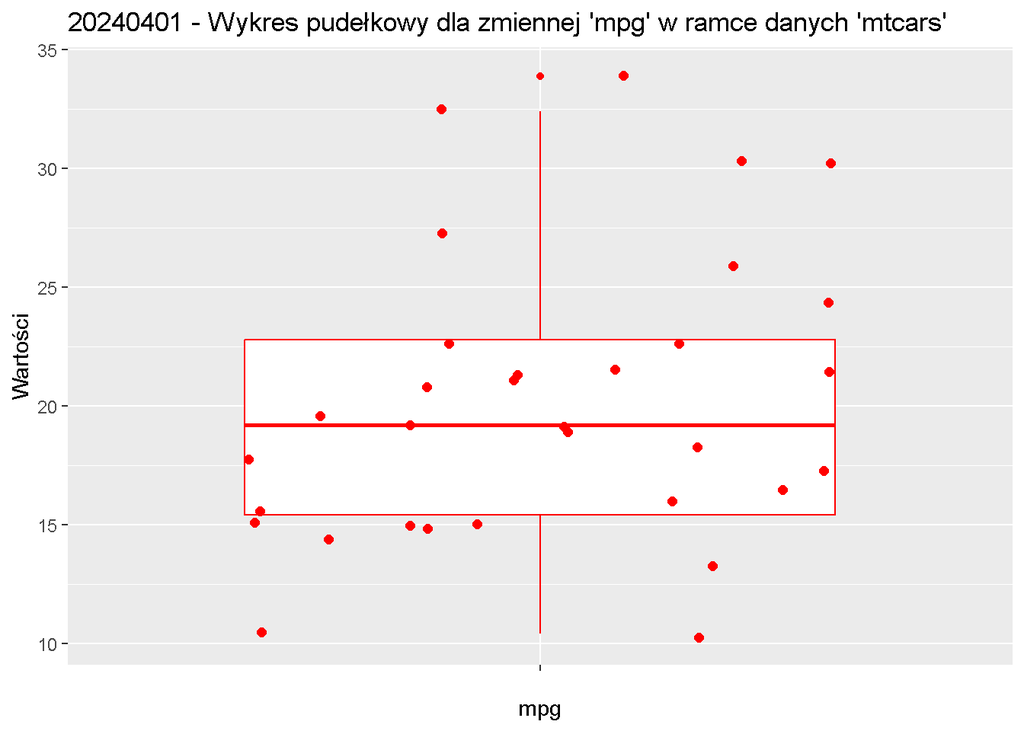

```r
# Wykres pudełkowy dla zmiennej: mpg
nazwa_zmiennej <- "mpg"
kolor_wykresu_i_punktów <- "red"
tytul_wykresu <- paste("20240401 - Wykres pudełkowy dla zmiennej '",
                      nazwa_zmiennej,"' w ramce danych 'mtcars'", sep="")
mtcars %>%
  select(mpg) %>%
  ggplot(aes(x = "", y = mpg)) +
  geom_boxplot(aes(y = mpg), color = kolor_wykresu_i_punktów) +
  geom_jitter(height = 0.2, color = kolor_wykresu_i_punktów, size = 2) +
  labs(title = tytul_wykresu,
       x = nazwa_zmiennej,
       y = "Wartości")
```

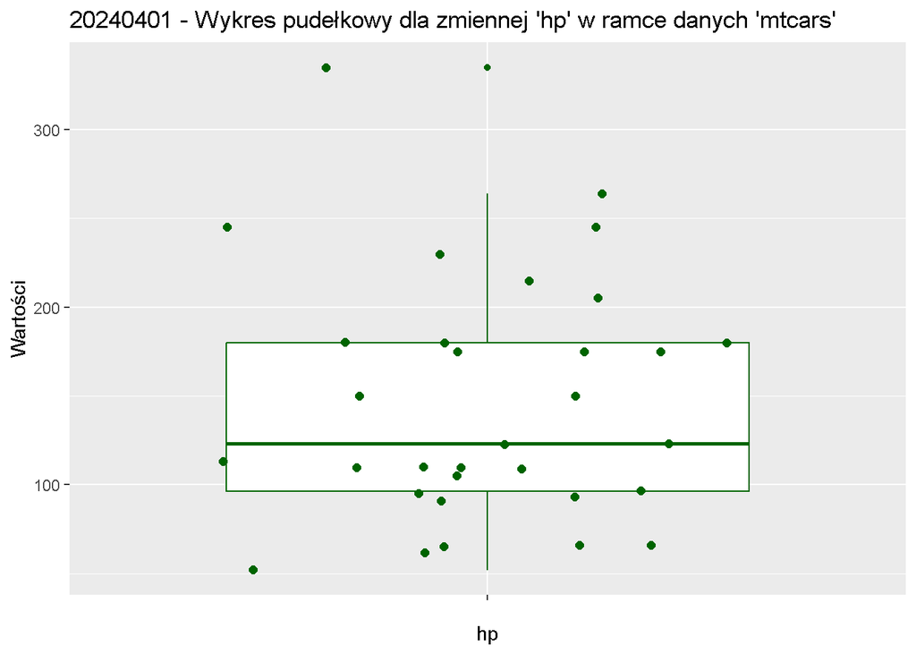

```r
# Wykres pudełkowy dla zmiennej: hp
nazwa_zmiennej = "hp"
kolor_wykresu_i_punktów = "darkgreen"
tytul_wykresu = paste("20240401 - Wykres pudełkowy dla zmiennej '",
                      nazwa_zmiennej,"' w ramce danych 'mtcars'", sep="")
mtcars %>%
  select(hp) %>%
  ggplot(aes(x = "", y = hp)) +
  geom_boxplot(aes(y = hp), color = kolor_wykresu_i_punktów) +
  geom_jitter(height = 0.2, color = kolor_wykresu_i_punktów, size = 2) +
  labs(title = tytul_wykresu,
       x = nazwa_zmiennej,
       y = "Wartości")
```

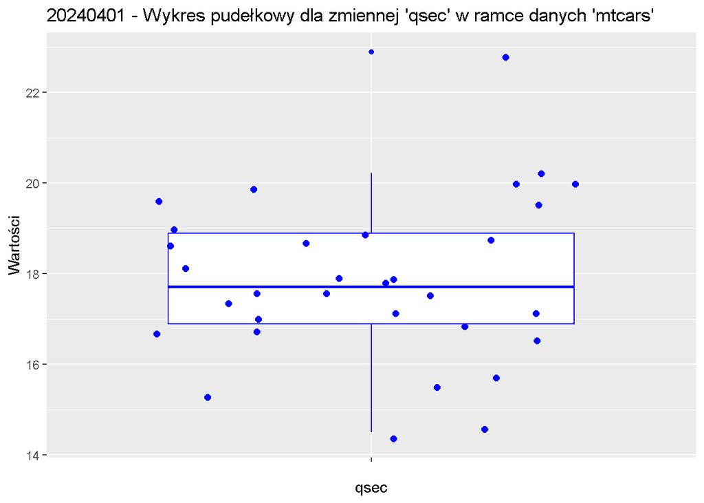

```r
# Wykres pudełkowy dla zmiennej: qsec
nazwa_zmiennej = "qsec"
kolor_wykresu_i_punktów = "blue"
tytul_wykresu = paste("20240401 - Wykres pudełkowy dla zmiennej '",
                      nazwa_zmiennej,"' w ramce danych 'mtcars'", sep="")
mtcars %>%
  select(qsec) %>%
  ggplot(aes(x = "", y = qsec)) +
  geom_boxplot(aes(y = qsec), color = kolor_wykresu_i_punktów) +
  geom_jitter(height = 0.2, color = kolor_wykresu_i_punktów, size = 2) +
  labs(title = tytul_wykresu,
       x = nazwa_zmiennej,
       y = "Wartości")
```

### Zestaw 1 - Zadanie numer 8

Oryginalna treść zadania:

*“Swietnym narzedziem statystycznym dla psychologow jest pakiet psych, ktory miesci wiele potrzebnych i waznych dla nich funkcji.”*

#### Zestaw 1 - Podpunkt 8.a

Oryginalna treść podpunktu:

*“zainstaluj ten pakiet, a nastepnie wczytaj go do pamieci (funkcja library()).”*

Rozwiązanie podpunktu:

```r
library(psych)
```

#### Zestaw 1 - Podpunkt 8.b

Oryginalna treść podpunktu:

*“W pakiecie psych istnieje funkcja describe. Postaraj sie, za jej pomoca, wyswietlic statytyski opisowe dla danych mtcars. Czym sie ona rozni od funkcji summary().”*

Rozwiązanie podpunktu:

```r
describe(mtcars)
```

```
##      vars  n   mean     sd median trimmed    mad   min    max  range  skew
## mpg     1 32  20.09   6.03  19.20   19.70   5.41 10.40  33.90  23.50  0.61
## cyl     2 32   6.19   1.79   6.00    6.23   2.97  4.00   8.00   4.00 -0.17
## disp    3 32 230.72 123.94 196.30  222.52 140.48 71.10 472.00 400.90  0.38
## hp      4 32 146.69  68.56 123.00  141.19  77.10 52.00 335.00 283.00  0.73
## drat    5 32   3.60   0.53   3.70    3.58   0.70  2.76   4.93   2.17  0.27
## wt      6 32   3.22   0.98   3.33    3.15   0.77  1.51   5.42   3.91  0.42
## qsec    7 32  17.85   1.79  17.71   17.83   1.42 14.50  22.90   8.40  0.37
## vs      8 32   0.44   0.50   0.00    0.42   0.00  0.00   1.00   1.00  0.24
## am      9 32   0.41   0.50   0.00    0.38   0.00  0.00   1.00   1.00  0.36
## gear   10 32   3.69   0.74   4.00    3.62   1.48  3.00   5.00   2.00  0.53
## carb   11 32   2.81   1.62   2.00    2.65   1.48  1.00   8.00   7.00  1.05
##      kurtosis    se
## mpg     -0.37  1.07
## cyl     -1.76  0.32
## disp    -1.21 21.91
## hp      -0.14 12.12
## drat    -0.71  0.09
## wt      -0.02  0.17
## qsec     0.34  0.32
## vs      -2.00  0.09
## am      -1.92  0.09
## gear    -1.07  0.13
## carb     1.26  0.29
```

W ślad za [6], funkcja ‘describe()’:  
- opis ogólny: wykorzystywana do testów psychometrycznych i budowy skal psychologicznych,  
- argument wejściowy: ramka danych lub matryca,  
- argumenty wyjściowe dla każdej kolumny ramki danych: liczba elementów każdej kolumny, średnia, mediana (drugi kwartyl), średnie odchylenie bezwzględne, wartość minimalna, wartość maksymalna, zakres min-max, skośność, kurtoza, błąd standardowy.

```r
summary(mtcars)
```

```
##       mpg             cyl             disp             hp
##  Min.   :10.40   Min.   :4.000   Min.   : 71.1   Min.   : 52.0
##  1st Qu.:15.43   1st Qu.:4.000   1st Qu.:120.8   1st Qu.: 96.5
##  Median :19.20   Median :6.000   Median :196.3   Median :123.0
##  Mean   :20.09   Mean   :6.188   Mean   :230.7   Mean   :146.7
##  3rd Qu.:22.80   3rd Qu.:8.000   3rd Qu.:326.0   3rd Qu.:180.0
##  Max.   :33.90   Max.   :8.000   Max.   :472.0   Max.   :335.0
##       drat             wt             qsec             vs
##  Min.   :2.760   Min.   :1.513   Min.   :14.50   Min.   :0.0000
##  1st Qu.:3.080   1st Qu.:2.581   1st Qu.:16.89   1st Qu.:0.0000
##  Median :3.695   Median :3.325   Median :17.71   Median :0.0000
##  Mean   :3.597   Mean   :3.217   Mean   :17.85   Mean   :0.4375
##  3rd Qu.:3.920   3rd Qu.:3.610   3rd Qu.:18.90   3rd Qu.:1.0000
##  Max.   :4.930   Max.   :5.424   Max.   :22.90   Max.   :1.0000
##        am              gear            carb
##  Min.   :0.0000   Min.   :3.000   Min.   :1.000
##  1st Qu.:0.0000   1st Qu.:3.000   1st Qu.:2.000
##  Median :0.0000   Median :4.000   Median :2.000
##  Mean   :0.4062   Mean   :3.688   Mean   :2.812
##  3rd Qu.:1.0000   3rd Qu.:4.000   3rd Qu.:4.000
##  Max.   :1.0000   Max.   :5.000   Max.   :8.000
```

W ślad za [7], funkcja ‘summary()’:  
- opis ogólny: ogólna funkcja wbudowana służąca podsumowaniom,  
- argument wejściowy: jakikolwiek obiekt R,  
- argumenty wyjściowe dla każdej kolumny: wartość minimalna, pierwszy kwartyl, mediana (drugi kwartyl), średnia, trzeci kwartyl, wartość maksymalna.

W mojej ocenie, główna różnica między funkcjami ‘describe()’ oraz ‘summary()’ jest taka, że ‘describe()’ zwraca większą liczbę parametrów opisowych, niż ‘summary()’. Dodatkowo, ‘describe()’ jest dla mnie osobiście bardziej czytelna i umożliwia łatwiejsze porównywanie ze sobą kolumn. Stąd właśnie zaleta ‘describe()’ związana z budową skal.

### Zestaw 1 - Zadanie numer 9

Oryginalna treść zadania:

*“Na zajeciach uzywalismy funkcji sample(). Sluzy ona do losowania danych z pewnej proby. Argumenty tej funkcji to: x - mozliwe wyniki losowania, size - liczba wylosowanych liczb, replace - informacja, czy losujemy ze zwracaniem.”*

#### Zestaw 1 - Podpunkt 9.a

Oryginalna treść podpunktu:

*“Wygeneruj 20 wynikow rzutu kostka do gry. Nazwij te zmienna proba. Ile wynosi srednia i odchylenie standardowe?”*

Rozwiązanie podpunktu:

```r
proba <- sample(c(1,2,3,4,5,6), 20, replace = TRUE)
odchylenie_standardowe <- sd(proba)
print(paste("Odchylenie standardowe dla danej realizacji rzutu kostką zaokrąglone do 2 miejsce po przecinku:", round(odchylenie_standardowe,2)))
```

```
## [1] "Odchylenie standardowe dla danej realizacji rzutu kostką zaokrąglone do 2 miejsce po przecinku: 1.69"
```

```r
srednia <- mean(proba)
print(paste("Średnia dla danej realizacji rzutu kostką zaokrąglona do 2 miejsce po przecinku:", round(srednia,2)))
```

```
## [1] "Średnia dla danej realizacji rzutu kostką zaokrąglona do 2 miejsce po przecinku: 3.7"
```

#### Zestaw 1 - Podpunkt 9.b

Oryginalna treść podpunktu:

*“Wygeneruj 100 wynikow rzutu moneta. Nazwij te zmienna rzut (uwaga: jako 1 mozesz oznaczyc orla, jako 0 reszke). Ile wypadlo orlow?”*

Rozwiązanie podpunktu:

```r
rzuty_moneta <- sample(c(0,1), 100, replace = TRUE)
print(paste("Liczba 'Orłów', czyli wartości '1' dla danej realizacji rzutu monetą:",tabulate(rzuty_moneta)))
```

```
## [1] "Liczba 'Orłów', czyli wartości '1' dla danej realizacji rzutu monetą: 47"
```

#### Zestaw 1 - Podpunkt 9.c

Oryginalna treść podpunktu:

*“Wylosuj (bez zwracania) 10 liczb ze zbioru liczb naturalnych od 0 do 100.”*

Rozwiązanie podpunktu:

```r
posortowane_liczby_naturalne <- sort(sample(0:100, 10, replace = TRUE))
print(paste("Posortowane liczby naturalne dla danej realizacji:",
            paste(unlist(posortowane_liczby_naturalne), collapse=", ")))
```

```
## [1] "Posortowane liczby naturalne dla danej realizacji: 1, 5, 8, 9, 34, 41, 53, 75, 93, 98"
```

#### Zestaw 1 - Podpunkt 9.d

Oryginalna treść podpunktu:

*“Poznaj funkcje rnorm, rt oraz rpoisson. Na wymyslonym przez siebie przykladzie, zastosuj jedna z w/w funkcji.”*

Rozwiązanie podpunktu:

```r
# Realizacja losowania przy użyciu funkcji rnorm
liczba_elementow_zmiennej_losowej = 5000
srednia_zmiennej_losowej = 5
odchylenie_standardowe_zmiennej_losowej = 4
rozklad_normalny <- rnorm(liczba_elementow_zmiennej_losowej,
                          srednia_zmiennej_losowej,
                          odchylenie_standardowe_zmiennej_losowej)

# Test zgodności rozkładu zmiennej losowej z rozkładem normalnym
print("Test zgodności rozkładu zmiennej losowej wygenerowanej przy użyciu 'rnorm()' z rozkładem normalnym Shapiro-Wilk:")
```

```
## [1] "Test zgodności rozkładu zmiennej losowej wygenerowanej przy użyciu 'rnorm()' z rozkładem normalnym Shapiro-Wilk:"
```

```r
output_testu_shapiro_wilk <- shapiro.test(rozklad_normalny)
wartosc_p_value <- output_testu_shapiro_wilk[2]
wartosc_p_value <- round(as.numeric(wartosc_p_value),3)
wartosc_p_value
```

```
## [1] 0.472
```

```r
print("Przyjmując poziom istotności alfa = 0.05, brak podstaw do stwierdzenia, że zmienna ma rozkład inny niż normalny. Brak podstaw do odrzucenia hipotezy zerowej testu Shapiro-Wilka.")
```

```
## [1] "Przyjmując poziom istotności alfa = 0.05, brak podstaw do stwierdzenia, że zmienna ma rozkład inny niż normalny. Brak podstaw do odrzucenia hipotezy zerowej testu Shapiro-Wilka."
```

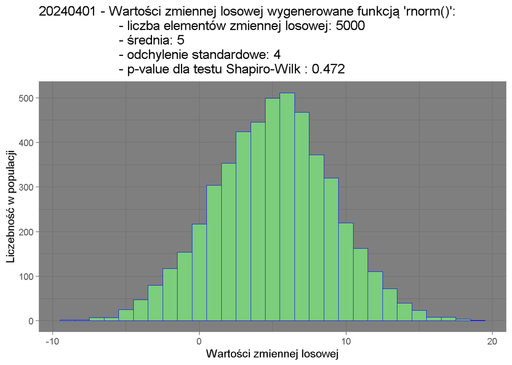

```r
# Histogram wektora wartości zmiennej losowej
dlugosc_wektora_rozklad_normalny <- length(rozklad_normalny)
ggplot() + aes(rozklad_normalny) +
  geom_histogram(binwidth
                 = dlugosc_wektora_rozklad_normalny
                 /liczba_elementow_zmiennej_losowej,
                 fill = "palegreen3", colour = "blue", linewidth = 0.1) +
  theme_dark() +
  labs(title = paste("20240401 - Wartości zmiennej losowej wygenerowane funkcją 'rnorm()':
                     - liczba elementów zmiennej losowej:", liczba_elementow_zmiennej_losowej,"
                     - średnia:", srednia_zmiennej_losowej,"
                     - odchylenie standardowe:", odchylenie_standardowe_zmiennej_losowej,"
                     - p-value dla testu Shapiro-Wilk :"
                     ,wartosc_p_value), x = "Wartości zmiennej losowej", y="Liczebność w populacji")
```

## Zestaw zadań 2

### Zestaw 2 - Zadanie numer 2

Oryginalna treść zadania:

*“Stworz zestaw danych lista wg instrukcji ponizej:”*

Rozwiązanie powyższego wymagania wstępnego:

```r
lista <- list(palenie = c(F,T,T,F,F,T,F),
              cyfry = 0:9,
              macierz = matrix(sample(1:5,16,replace = T),4,4),
              tekst = c("Litwo", "ojczyzno", "moja", "ty",
                         "jestes", "jak", "zdrowie"))
```

#### Zestaw 2 - Podpunkt 2.a

Oryginalna treść podpunktu:

*“Odwolaj sie do obiektu tekst.”*

Rozwiązanie podpunktu:

```r
# Odwoływanie się do elementów listy przy użyciu nazw elementów - metoda tekstowa
print(lista["tekst"])
```

```
## $tekst
## [1] "Litwo"    "ojczyzno" "moja"     "ty"       "jestes"   "jak"      "zdrowie"
```

```r
print(lista[["tekst"]][2])
```

```
## [1] "ojczyzno"
```

```r
print(lista[["tekst"]][2:5])
```

```
## [1] "ojczyzno" "moja"     "ty"       "jestes"
```

```r
# Odwoływanie się do elementów listy przy użyciu nazw elementów - metoda ze znakiem '$'
print(lista$tekst)
```

```
## [1] "Litwo"    "ojczyzno" "moja"     "ty"       "jestes"   "jak"      "zdrowie"
```

```r
print(lista$tekst[2])
```

```
## [1] "ojczyzno"
```

```r
print(lista$tekst[2:5])
```

```
## [1] "ojczyzno" "moja"     "ty"       "jestes"
```

```r
# Odwoływanie się do elementów listy przy użyciu indeksów
print(lista[4])
```

```
## $tekst
## [1] "Litwo"    "ojczyzno" "moja"     "ty"       "jestes"   "jak"      "zdrowie"
```

```r
print(lista[[4]][2])
```

```
## [1] "ojczyzno"
```

```r
print(lista[[4]][2:5])
```

```
## [1] "ojczyzno" "moja"     "ty"       "jestes"
```

#### Zestaw 2 - Podpunkt 2.b

Oryginalna treść podpunktu:

*“Odwolaj sie do trzeciego elementu wektora cyfry.”*

Rozwiązanie podpunktu:

```r
# Odwoływanie się do elementów listy przy użyciu nazw elementów - metoda tekstowa
print(lista[["cyfry"]][3])
```

```
## [1] 2
```

```r
# Odwoływanie się do elementów listy przy użyciu nazw elementów - metoda ze znakiem '$'
print(lista$cyfry[3])
```

```
## [1] 2
```

```r
# Odwoływanie się do elementów listy przy użyciu indeksów
print(lista[[2]][3])
```

```
## [1] 2
```

#### Zestaw 2 - Podpunkt 2.c

Oryginalna treść podpunktu:

*“Odwolaj sie do trzeciej kolumny obiektu macierz.”*

Rozwiązanie podpunktu:

```r
# Odwoływanie się do elementów listy przy użyciu nazw elementów - metoda tekstowa
print(lista[["macierz"]][,3])
```

```
## [1] 1 3 2 3
```

```r
# Odwoływanie się do elementów listy przy użyciu nazw elementów - metoda ze znakiem '$'
print(lista$macierz[,3])
```

```
## [1] 1 3 2 3
```

```r
# Odwoływanie się do elementów listy przy użyciu indeksów
print(lista[[3]][,3])
```

```
## [1] 1 3 2 3
```

### Zestaw 2 - Zadanie numer 3

Oryginalna treść zadania:

*“Uzyj instrukcji if-else oraz funkcji ifesle() do sprawdzenia, czy dowolna liczba jest podzielna przez 5.”*

Rozwiązanie zadania:

```r
# Rozwiązanie z wykorzystaniem struktury warunkowej 'if-else', pętli 'for' oraz operatora zakresu/przynależności 'in'.
liczby_do_sprawdzenia <- c(3,5,7,10,11,15,17,25,27,30)
dlugosc_wektora_liczb <- length(liczby_do_sprawdzenia)

for (iterator in 1:dlugosc_wektora_liczb)
{
  obecna_liczba_do_sprawdzenia <- liczby_do_sprawdzenia[iterator]
  reszta_z_dzielenia_danej_liczby_przez_piec <- obecna_liczba_do_sprawdzenia %% 5

  if(reszta_z_dzielenia_danej_liczby_przez_piec == 0)
  {
    print(paste("Liczba",obecna_liczba_do_sprawdzenia,"jest podzielna przez pięć."))
  }else
  {
    print(paste("Liczba",obecna_liczba_do_sprawdzenia," nie jest podzielna przez pięć."))
  }
}
```

```
## [1] "Liczba 3  nie jest podzielna przez pięć."
## [1] "Liczba 5 jest podzielna przez pięć."
## [1] "Liczba 7  nie jest podzielna przez pięć."
## [1] "Liczba 10 jest podzielna przez pięć."
## [1] "Liczba 11  nie jest podzielna przez pięć."
## [1] "Liczba 15 jest podzielna przez pięć."
## [1] "Liczba 17  nie jest podzielna przez pięć."
## [1] "Liczba 25 jest podzielna przez pięć."
## [1] "Liczba 27  nie jest podzielna przez pięć."
## [1] "Liczba 30 jest podzielna przez pięć."
```

```r
# Rozwiązanie z wykorzystaniem struktury warunkowej 'else-if', pętli 'for' oraz operatora zakresu/przynależności 'in'.
liczby_do_sprawdzenia <- c(3,5,7,10,11,15,17,25,27,30)
dlugosc_wektora_liczb <- length(liczby_do_sprawdzenia)

for (iterator in 1:dlugosc_wektora_liczb)
{
  obecna_liczba_do_sprawdzenia <- liczby_do_sprawdzenia[iterator]
  reszta_z_dzielenia_danej_liczby_przez_piec <- obecna_liczba_do_sprawdzenia %% 5

  if(reszta_z_dzielenia_danej_liczby_przez_piec == 0)
  {
    print(paste("Liczba",obecna_liczba_do_sprawdzenia,"jest podzielna przez pięć."))
  }else if(reszta_z_dzielenia_danej_liczby_przez_piec != 0)
  {
    print(paste("Liczba",obecna_liczba_do_sprawdzenia," nie jest podzielna przez pięć."))
  }
}
```

```
## [1] "Liczba 3  nie jest podzielna przez pięć."
## [1] "Liczba 5 jest podzielna przez pięć."
## [1] "Liczba 7  nie jest podzielna przez pięć."
## [1] "Liczba 10 jest podzielna przez pięć."
## [1] "Liczba 11  nie jest podzielna przez pięć."
## [1] "Liczba 15 jest podzielna przez pięć."
## [1] "Liczba 17  nie jest podzielna przez pięć."
## [1] "Liczba 25 jest podzielna przez pięć."
## [1] "Liczba 27  nie jest podzielna przez pięć."
## [1] "Liczba 30 jest podzielna przez pięć."
```

### Zestaw 2 - Zadanie numer 4

Oryginalna treść zadania:

*“Stworz zmienna ksiazki mowiaca o tym, ile dana osoba przeczytala ksiazek w ostatnim kwartale. Zrob to wg instrukcji ponizej:”*

Rozwiązanie powyższego wymagania wstępnego:

```r
ksiazki <- sample(0:4, size = 25, replace = TRUE)
```

#### Zestaw 2 - Podpunkt 4.a

Oryginalna treść podpunktu:

*“Ile wynosi srednia liczby przeczytanych ksiazek?”*

Rozwiązanie podpunktu:

```r
srednia_liczba_przeczytanych_ksiazek <- mean(ksiazki)
print(paste("Dla danej realizacji losowania funkcji 'sample()', średnia arytmetyczna liczby przeczytanych książek wynosi:", srednia_liczba_przeczytanych_ksiazek))
```

```
## [1] "Dla danej realizacji losowania funkcji 'sample()', średnia arytmetyczna liczby przeczytanych książek wynosi: 2.16"
```

#### Zestaw 2 - Podpunkt 4.b

Oryginalna treść podpunktu:

*“Ile osob przeczytalo przynajmniej trzy ksiazki?”*

Rozwiązanie podpunktu:

```r
liczba_osob_ktore_przeczytaly_przynajmniej_trzy_ksiazki <- sum(ksiazki >= 3)
print(paste("Dla danej realizacji losowania funkcji 'sample()', liczba osób, które przeczytały przynajmniej trzy książki wynosi (czyli: 'ksiazki >= 3'):", liczba_osob_ktore_przeczytaly_przynajmniej_trzy_ksiazki))
```

```
## [1] "Dla danej realizacji losowania funkcji 'sample()', liczba osób, które przeczytały przynajmniej trzy książki wynosi (czyli: 'ksiazki >= 3'): 13"
```

#### Zestaw 2 - Podpunkt 4.c

Oryginalna treść podpunktu:

*“Ile osob nie przeczytalo zadnej ksiazki?”*

Rozwiązanie podpunktu:

```r
liczba_osob_ktore_nie_przeczytaly_zadnej_ksiazki <- sum(ksiazki == 0)
print(paste("Dla danej realizacji losowania funkcji 'sample()', liczba osób, które nie przeczytały żadnej książki wynosi (czyli: 'ksiazki == 0'):", liczba_osob_ktore_nie_przeczytaly_zadnej_ksiazki))
```

```
## [1] "Dla danej realizacji losowania funkcji 'sample()', liczba osób, które nie przeczytały żadnej książki wynosi (czyli: 'ksiazki == 0'): 6"
```

#### Zestaw 2 - Podpunkt 4.d

Oryginalna treść podpunktu:

*“Stworz zmienna ksiazki2, ktora bedzie mowila o tym, czy ktos czyta ksiazki (przeczytal min. jedna). Uzyj do tego petli for.”*

Rozwiązanie podpunktu:

```r
# Podpunkt: d - rozwiązanie z użyciem operatorów relacyjnych
ksiazki2 <- (sum(ksiazki >= 1) >= 1)
print(paste("Odpowiedź na pytanie, czy ktokolwiek w wylosowanej próbie przeczytał choćby jedną książkę brzmi:", ksiazki2))
```

```
## [1] "Odpowiedź na pytanie, czy ktokolwiek w wylosowanej próbie przeczytał choćby jedną książkę brzmi: TRUE"
```

```r
# Podpunkt: d - rozwiązanie z użyciem pętli 'for'
dlugosc_wektora_ksiazki <- length(ksiazki)
for (iterator in 1:dlugosc_wektora_ksiazki)
{
  obecny_element_wektora_ksiazki <- ksiazki[iterator]
  if(obecny_element_wektora_ksiazki >= 1)
  {
    print(paste("Przynajmniej jedna osoba w wylosowanej próbie przeczytała choćby jedną książkę. Jest to osoba na",iterator," pozycji wektora 'ksiazki'. Przerywam dalsze szukanie!"))
    break
  }
}
```

```
## [1] "Przynajmniej jedna osoba w wylosowanej próbie przeczytała choćby jedną książkę. Jest to osoba na 2  pozycji wektora 'ksiazki'. Przerywam dalsze szukanie!"
```

### Zestaw 2 - Zadanie numer 5

Oryginalna treść zadania:

*“Stworz instrukcje warunkowa, ktora majac date (miesiac i rok) odpowie na pytanie o liczbe dni w tym miesiacu.”*

Rozwiązanie powyższego wymagania wstępnego:

```r
# Import modułów, bibliotek oraz konfiguracja
library(lubridate)

# Dane wejściowe
numeric_rok <- 2011
numeric_miesiac <- 9

# Funkcja do obliczenia liczby dni w danym miesiącu
oblicz_liczbe_dni <- function(rok, miesiac){

    rok <- as.character(rok)

    if (miesiac < 10){
      miesiac <- as.character(miesiac)
      miesiac <- paste0("0",miesiac)
    }else
    {
      miesiac <- as.character(miesiac)
    }

    rok_miesiac <- paste0(rok,"-",miesiac,"-01")

    obiekt_daty <- as.Date(rok_miesiac, "%Y-%m-%d")
    return(as.numeric(lubridate::days_in_month(obiekt_daty)))
}

# Wywołanie funkcji oblicz_liczbe_dni()
liczba_dni <- oblicz_liczbe_dni(numeric_rok, numeric_miesiac)
print(paste0("W ",numeric_miesiac,". miesiącu ",
             numeric_rok," roku jest ", liczba_dni," dni."))
```

```
## [1] "W 9. miesiącu 2011 roku jest 30 dni."
```

## Zestaw zadań 3

### Zestaw 3 - Zadanie numer 2

Oryginalna treść zadania:

*“Wśród udostępnionych plików jest plik o nazwie budzety2005. Proszę go wczytać - zmienne jakościowe proszę wgrać jako faktory. Wykorzystując znane funkcje (np. str(), head() i summary()), spróbuj szybko zapoznać się z tym zestawem danych.”*

*“Na początku proszę zastanowić się, co oznacza zmienna townsize - jeśli to konieczne zmienić jej poziomy (automatycznie są one alfabetyczne, a to chyba nie jest dobry wybór).”*

*“Następnie, z wykorzystaniem odpowiednich funkcji pakietu dplyr, proszę wykonać kolejne polecenia:”*

Rozwiązanie powyższego wymagania wstępnego:

```r
### Import modułów oraz bibliotek
library(plyr)

### Import plików danych, wstępna analiza oraz konfiguracja danych
# Import pliku "budzety2005.csv".
# Zmienne jakościowe (np. stringi) są wczytywane jako "factors".
obecny_katalog <- getwd()
setwd(obecny_katalog)
obecny_katalog <- paste0(obecny_katalog,"/budzety2005.csv")
obecny_katalog
```

```
## [1] "Y:/General/Admin Obecne/Numeri/Wyklady Materialy/Analiza danych w R/Unikalne - Zaliczenia/20240330 - Projekt R na zaliczenie/budzety2005.csv"
```

```r
ramka_danych_budzety2005 <- read.csv(obecny_katalog, stringsAsFactors=TRUE)

# Wstępna analiza danych przy użyciu funkcji str(), head(), tail(), summary() oraz sapply()
str(ramka_danych_budzety2005)
```

```
## 'data.frame':    30003 obs. of  67 variables:
##  $ X             : int  1 2 3 4 5 6 7 8 9 10 ...
##  $ hhno          : int  222670321 112100821 210021011 200570421 200010521 200200611 111980621 222930321 100840521 210820521 ...
##  $ famno         : int  1 1 1 1 1 1 1 1 1 1 ...
##  $ persno        : int  1 1 1 1 1 1 1 1 1 1 ...
##  $ reltohoh      : Factor w/ 6 levels " head "," husband/wife ",..: 1 1 1 1 1 1 1 1 1 1 ...
##  $ hoh           : int  1 1 1 1 1 1 1 1 1 1 ...
##  $ reltohof      : Factor w/ 3 levels "Dep. child","Head",..: 2 2 2 2 2 2 2 2 2 2 ...
##  $ hofam         : int  1 1 1 1 1 1 1 1 1 1 ...
##  $ month_hh      : int  3 8 10 4 5 6 6 3 5 5 ...
##  $ townsize      : Factor w/ 6 levels "100,000 - 199,999",..: 6 5 1 4 3 4 5 6 3 2 ...
##  $ wojregion     : Factor w/ 16 levels "Dolnoslaskie",..: 6 3 1 7 16 15 6 7 12 3 ...
##  $ farmsize      : num  0 0 0 0 0 0 0 0 0 0 ...
##  $ farmnoeq      : num  0 0 0 0 0 0 0 0 0 0 ...
##  $ buildtype     : Factor w/ 4 levels "free standing",..: 1 2 2 2 2 2 1 2 2 2 ...
```

[output cut: 53 more lines]

```r
head(ramka_danych_budzety2005, 5)
```

```
##   X      hhno famno persno reltohoh hoh reltohof hofam month_hh
## 1 1 222670321     1      1    head    1     Head     1        3
## 2 2 112100821     1      1    head    1     Head     1        8
## 3 3 210021011     1      1    head    1     Head     1       10
## 4 4 200570421     1      1    head    1     Head     1        4
## 5 5 200010521     1      1    head    1     Head     1        5
##            townsize          wojregion farmsize farmnoeq     buildtype flatsize
## 1          villages        Malopolskie        0        0 free standing       80
## 2 town up to 19,999            Lodzkie        0        0    multi-flat       18
## 3 100,000 - 199,999       Dolnoslaskie        0        0    multi-flat       29
## 4  500,000 and over        Mazowieckie        0        0    multi-flat       28
## 5 200,000 - 499,999 Zachodniopomorskie        0        0    multi-flat       53
##    bills weightYint weightPers OECDeqsH OECDeqsF eq_GUSincome eq_DATAincome
## 1 111.72        523        523        1        1       550.00       550.000
## 2 740.78        632        632        1        1      1061.86      1046.060
```

[output cut: 39 more lines]

```r
tail(ramka_danych_budzety2005, 5)
```

```
##           X      hhno famno persno               reltohoh hoh   reltohof hofam
## 29999 29999 120021221     1      1                  head    1     Spouse     0
## 30000 30000 120021221     2      5  mother/father(in law)   0       Head     1
## 30001 30001 120021221     1      4          son/daughter    0 Dep. child     0
## 30002 30002 120021221     1      2          husband/wife    0       Head     1
## 30003 30003 120021221     1      3          son/daughter    0 Dep. child     0
##       month_hh townsize   wojregion farmsize farmnoeq     buildtype flatsize
## 29999       12 villages Malopolskie     1.12        0 free standing      160
## 30000       12 villages Malopolskie     1.12        0 free standing      160
## 30001       12 villages Malopolskie     1.12        0 free standing      160
## 30002       12 villages Malopolskie     1.12        0 free standing      160
## 30003       12 villages Malopolskie     1.12        0 free standing      160
##       bills weightYint weightPers OECDeqsH OECDeqsF eq_GUSincome eq_DATAincome
## 29999 301.7        345       1725        3      2.5     633.8333           546
## 30000 301.7        345       1725        3      1.0     633.8333           546
```

[output cut: 45 more lines]

```r
summary(ramka_danych_budzety2005)
```

```
##        X              hhno               famno           persno
##  Min.   :    1   Min.   :100010111   Min.   :1.000   Min.   :1.000
##  1st Qu.: 7502   1st Qu.:112000421   1st Qu.:1.000   1st Qu.:1.000
##  Median :15002   Median :200431221   Median :1.000   Median :2.000
##  Mean   :15002   Mean   :165772914   Mean   :1.161   Mean   :2.007
##  3rd Qu.:22503   3rd Qu.:212550221   3rd Qu.:1.000   3rd Qu.:3.000
##  Max.   :30003   Max.   :223271211   Max.   :5.000   Max.   :8.000
##
##                    reltohoh          hoh               reltohof
##   head                 :12745   Min.   :0.0000   Dep. child: 6541
##   husband/wife         : 6971   1st Qu.:0.0000   Head      :16238
##   mother/father(in law):  762   Median :0.0000   Spouse    : 7224
##   not related          :  460   Mean   :0.4248
##   other relative       :  710   3rd Qu.:1.0000
##   son/daughter         : 8355   Max.   :1.0000
##
##      hofam           month_hh                  townsize
##  Min.   :0.0000   Min.   : 1.00   100,000 - 199,999: 2288
##  1st Qu.:0.0000   1st Qu.: 4.00   20,000  - 99,999 : 6059
##  Median :1.0000   Median : 7.00   200,000 - 499,999: 3142
##  Mean   :0.5412   Mean   : 6.54   500,000 and over : 4047
##  3rd Qu.:1.0000   3rd Qu.:10.00   town up to 19,999: 3431
##  Max.   :1.0000   Max.   :12.00   villages         :11036
##
##          wojregion        farmsize           farmnoeq
##  Mazowieckie  : 4187   Min.   :  0.0000   Min.   :  0.0000
##  Slaskie      : 3773   1st Qu.:  0.0000   1st Qu.:  0.0000
##  Dolnoslaskie : 2515   Median :  0.0000   Median :  0.0000
##  Malopolskie  : 2428   Mean   :  0.7011   Mean   :  0.0744
##  Wielkopolskie: 2400   3rd Qu.:  0.0000   3rd Qu.:  0.0000
##  Lodzkie      : 2348   Max.   :144.7800   Max.   :123.9000
##  (Other)      :12352
##          buildtype        flatsize          bills          weightYint
##  free standing:11311   Min.   :  0.00   Min.   :   0.0   Min.   :215
##  multi-flat   :16901   1st Qu.: 45.00   1st Qu.: 153.1   1st Qu.:344
##  other        :  103   Median : 59.00   Median : 281.7   Median :366
##  terrace/twin : 1688   Mean   : 68.48   Mean   : 321.6   Mean   :377
##                        3rd Qu.: 80.00   3rd Qu.: 427.7   3rd Qu.:387
##                        Max.   :400.00   Max.   :3783.0   Max.   :888
##
```

[output cut: 89 more lines]

```
##  Min.   :   0.000   Min.   :   0.00   Min.   :   0.00   Min.   :    0
##  1st Qu.:   0.000   1st Qu.:   0.00   1st Qu.:   0.00   1st Qu.:    0
##  Median :   0.000   Median :   0.00   Median :   0.00   Median :    0
##  Mean   :   1.708   Mean   :  67.95   Mean   :  14.93   Mean   :  205
##  3rd Qu.:   0.000   3rd Qu.:  42.99   3rd Qu.:   0.00   3rd Qu.:    0
##  Max.   :1600.000   Max.   :8000.00   Max.   :6219.00   Max.   :19170
##
##     emptype          random             random1
##  Min.   :0.000   Min.   :0.0000031   Min.   :0.000156
##  1st Qu.:0.000   1st Qu.:0.1738282   1st Qu.:0.400592
##  Median :0.000   Median :0.3439706   Median :0.539429
##  Mean   :0.519   Mean   :0.3456209   Mean   :0.496856
##  3rd Qu.:1.000   3rd Qu.:0.5181219   3rd Qu.:0.628362
##  Max.   :2.000   Max.   :0.6917575   Max.   :0.691758
##  NA's   :4006
```

```r
print("Przy użyciu funkcji 'sapply();, listuję wszystkie poziomy we wszystkich kolumnach ramki danych:")
```

```
## [1] "Przy użyciu funkcji 'sapply();, listuję wszystkie poziomy we wszystkich kolumnach ramki danych:"
```

```r
sapply(ramka_danych_budzety2005, levels)
```

```
## $X
## NULL
##
## $hhno
## NULL
##
## $famno
## NULL
##
## $persno
## NULL
##
## $reltohoh
## [1] " head "                 " husband/wife "         " mother/father(in law)"
## [4] " not related "          " other relative"        " son/daughter "
##
## $hoh
## NULL
##
## $reltohof
## [1] "Dep. child" "Head"       "Spouse"
##
## $hofam
## NULL
##
## $month_hh
## NULL
##
## $townsize
## [1] "100,000 - 199,999" "20,000  - 99,999"  "200,000 - 499,999"
## [4] "500,000 and over"  "town up to 19,999" "villages"
##
## $wojregion
##  [1] "Dolnoslaskie"        "Kujawsko-pomorskie"  "Lodzkie"
##  [4] "Lubelskie"           "Lubuskie"            "Malopolskie"
##  [7] "Mazowieckie"         "Opolskie"            "Podkarpackie"
## [10] "Podlaskie"           "Pomorskie"           "Slaskie"
## [13] "Swietokrzyskie"      "Warminsko-mazurskie" "Wielkopolskie"
## [16] "Zachodniopomorskie"
##
```

[output cut: 164 more lines]

```
##
## $mortgage
## NULL
##
## $exfarm
## NULL
##
## $emptype
## NULL
##
## $random
## NULL
##
## $random1
## NULL
```

```r
# Analiza zmiennej "townsize" w ramce danych oraz re-konfiguracja jej poziomów ("levels")
print(paste("Sprawdzam czy 'townsize' ma format 'factor':", is.factor(ramka_danych_budzety2005$townsize)))
```

```
## [1] "Sprawdzam czy 'townsize' ma format 'factor': TRUE"
```

```r
print("Wylistowanie pierwszych dziesięciu wartości faktora 'townsize' przed re-konfiguracją poziomów:")
```

```
## [1] "Wylistowanie pierwszych dziesięciu wartości faktora 'townsize' przed re-konfiguracją poziomów:"
```

```r
ramka_danych_budzety2005$townsize[1:10]
```

```
##  [1] villages          town up to 19,999 100,000 - 199,999 500,000 and over
##  [5] 200,000 - 499,999 500,000 and over  town up to 19,999 villages
##  [9] 200,000 - 499,999 20,000  - 99,999
## 6 Levels: 100,000 - 199,999 20,000  - 99,999 ... villages
```

```r
print("Wylistowanie poziomów faktora 'townsize' przed ich re-konfiguracją:")
```

```
## [1] "Wylistowanie poziomów faktora 'townsize' przed ich re-konfiguracją:"
```

```r
levels(ramka_danych_budzety2005$townsize)
```

```
## [1] "100,000 - 199,999" "20,000  - 99,999"  "200,000 - 499,999"
## [4] "500,000 and over"  "town up to 19,999" "villages"
```

```r
print("Rekonfiguracja poziomów faktora 'townsize':")
```

```
## [1] "Rekonfiguracja poziomów faktora 'townsize':"
```

```r
ramka_danych_budzety2005$townsize <- plyr::revalue(ramka_danych_budzety2005$townsize,
                                             c("villages" = "Wioska",
                                               "town up to 19,999" = "Miasto do 19.999",
                                               "20,000  - 99,999" = "Miasto do 99.999",
                                               "100,000 - 199,999" = "Miasto do 199.999",
                                               "200,000 - 499,999" = "Miasto do 499.999",
                                               "500,000 and over" = "Miasto ponad 500.000")
                                             )

print("Wylistowanie poziomów faktora 'townsize' po ich re-konfiguracji:")
```

```
## [1] "Wylistowanie poziomów faktora 'townsize' po ich re-konfiguracji:"
```

```r
levels(ramka_danych_budzety2005$townsize)
```

```
## [1] "Miasto do 199.999"    "Miasto do 99.999"     "Miasto do 499.999"
## [4] "Miasto ponad 500.000" "Miasto do 19.999"     "Wioska"
```

```r
print("Wylistowanie pierwszych dziesięciu wartości faktora 'townsize' po re-konfiguracji poziomów:")
```

```
## [1] "Wylistowanie pierwszych dziesięciu wartości faktora 'townsize' po re-konfiguracji poziomów:"
```

```r
ramka_danych_budzety2005$townsize[1:10]
```

```
##  [1] Wioska               Miasto do 19.999     Miasto do 199.999
##  [4] Miasto ponad 500.000 Miasto do 499.999    Miasto ponad 500.000
##  [7] Miasto do 19.999     Wioska               Miasto do 499.999
## [10] Miasto do 99.999
## 6 Levels: Miasto do 199.999 Miasto do 99.999 ... Wioska
```

#### Zestaw 3 - Podpunkty 2.1 i 2.2

Oryginalna treść podpunktu 2.1:

*“Wybrać zmienne: townsize, wojregion, totincGUS, totexpGUS, sex, age married, buildtype, flatsize i hoh.”*

Oryginalna treść podpunktu 2.2:

*“Wprowadzić nowe nazwy zmiennych (wg uznania proszę przetłumaczyć owe odpowiedniki)”*

Rozwiązanie podpunktów:

```r
okrojona_ramka_danych_budzety_2005 <- ramka_danych_budzety2005 %>%
  select("Wielkosc_Miasta" = townsize,
         "Wojewodztwo" = wojregion,
         "Przychody" = totincGUS,
         "Wydatki" = totexpGUS,
         "Plec" = sex,
         "Wiek" = age,
         "Stan_Cywilny" = married,
         "Typ_Budynku" = buildtype,
         "Powierzchnia_Mieszkania" = flatsize,
         "Glowa_Rodziny" = hoh)
summary(okrojona_ramka_danych_budzety_2005)
```

```
##              Wielkosc_Miasta         Wojewodztwo      Przychody
##  Miasto do 199.999   : 2288   Mazowieckie  : 4187   Min.   :-83648
##  Miasto do 99.999    : 6059   Slaskie      : 3773   1st Qu.:  1302
##  Miasto do 499.999   : 3142   Dolnoslaskie : 2515   Median :  1931
##  Miasto ponad 500.000: 4047   Malopolskie  : 2428   Mean   :  2277
##  Miasto do 19.999    : 3431   Wielkopolskie: 2400   3rd Qu.:  2800
##  Wioska              :11036   Lodzkie      : 2348   Max.   : 85344
##                               (Other)      :12352
##     Wydatki             Plec            Wiek         Stan_Cywilny
##  Min.   :  104.4   female :16257   Min.   :  0.00   Min.   :0.0000
##  1st Qu.: 1182.2   male   :13746   1st Qu.: 23.00   1st Qu.:0.0000
##  Median : 1714.9                   Median : 44.00   Median :0.0000
##  Mean   : 2068.3                   Mean   : 41.36   Mean   :0.4817
##  3rd Qu.: 2501.2                   3rd Qu.: 58.00   3rd Qu.:1.0000
##  Max.   :28007.5                   Max.   :100.00   Max.   :1.0000
##
##         Typ_Budynku    Powierzchnia_Mieszkania Glowa_Rodziny
##  free standing:11311   Min.   :  0.00          Min.   :0.0000
##  multi-flat   :16901   1st Qu.: 45.00          1st Qu.:0.0000
##  other        :  103   Median : 59.00          Median :0.0000
##  terrace/twin : 1688   Mean   : 68.48          Mean   :0.4248
##                        3rd Qu.: 80.00          3rd Qu.:1.0000
##                        Max.   :400.00          Max.   :1.0000
##
```

#### Zestaw 3 - Podpunkt 2.3

Oryginalna treść podpunktu 2.3:

*“Wyfiltrować tylko te osoby, które mają dodatnie przychody i wydatki (zmienne: totincGUS, totexpGUS) oraz zmienna hoh przyjmuje wartość 1 (w ten sposób wyfiltrujemy tylko tzw. głowy rodziny.”*

Rozwiązanie podpunktu:

```r
przefiltrowana_ramka_danych <- okrojona_ramka_danych_budzety_2005 %>%
  filter(Przychody > 0, Wydatki > 0, Glowa_Rodziny == 1)
head(przefiltrowana_ramka_danych,5)
```

```
##        Wielkosc_Miasta        Wojewodztwo Przychody Wydatki    Plec Wiek
## 1               Wioska        Malopolskie    550.00  594.56    male   61
## 2     Miasto do 19.999            Lodzkie   1061.86 1694.38 female    81
## 3    Miasto do 199.999       Dolnoslaskie    623.00  697.31 female    56
## 4 Miasto ponad 500.000        Mazowieckie   1168.36 1430.45 female    56
## 5    Miasto do 499.999 Zachodniopomorskie   1735.94 1940.60 female    45
##   Stan_Cywilny   Typ_Budynku Powierzchnia_Mieszkania Glowa_Rodziny
## 1            0 free standing                      80             1
## 2            0    multi-flat                      18             1
## 3            0    multi-flat                      29             1
## 4            0    multi-flat                      28             1
## 5            0    multi-flat                      53             1
```

#### Zestaw 3 - Podpunkt 2.4

Oryginalna treść podpunktu 2.4:

*“Sprawdź, ile gospodarstw domowych mieszka danym województwie (użyć funkcji count()) oraz (osobno) ile osób mieszka w miejscowości każdej wielkości.”*

Rozwiązanie podpunktu:

```r
liczba_gospodarstw_domowych_w_danym_wojewodztwie <- okrojona_ramka_danych_budzety_2005 %>%
  count("Wojewodztwo")
liczba_gospodarstw_domowych_w_danym_wojewodztwie
```

```
##            Wojewodztwo freq
## 1         Dolnoslaskie 2515
## 2   Kujawsko-pomorskie 1518
## 3              Lodzkie 2348
## 4            Lubelskie 1724
## 5             Lubuskie  705
## 6          Malopolskie 2428
## 7          Mazowieckie 4187
## 8             Opolskie  869
## 9         Podkarpackie 1560
## 10           Podlaskie  888
## 11           Pomorskie 1673
## 12             Slaskie 3773
## 13      Swietokrzyskie  929
## 14 Warminsko-mazurskie 1121
## 15       Wielkopolskie 2400
## 16  Zachodniopomorskie 1365
```

```r
liczba_osob_w_danej_miejscowosci <- okrojona_ramka_danych_budzety_2005 %>%
  count("Wielkosc_Miasta")
liczba_osob_w_danej_miejscowosci
```

```
##        Wielkosc_Miasta  freq
## 1    Miasto do 199.999  2288
## 2     Miasto do 99.999  6059
## 3    Miasto do 499.999  3142
## 4 Miasto ponad 500.000  4047
## 5     Miasto do 19.999  3431
## 6               Wioska 11036
```

#### Zestaw 3 - Podpunkty 2.5 i 2.6

Oryginalna treść podpunktu 2.5:

*“Stworzyć zmienną oszczednosci, która jest zdefiniowana jako różnica między wydatkami i przychodem.”*

Oryginalna treść podpunktu 2.6:

*“Stworzyć zmienną oszczednosci_proc, która opisze oszczędności jako procent przychodu.”*

Rozwiązanie podpunktów:

Zmienną “Oszczedności” definiuję matematycznie jako: (Przychody - Wydatki)  
Zmienną “Oszczednosci_Proc” definuję matematycznie jako: 100*(Przychody - Wydatki)/Przychody

```r
ramka_danych_z_dodatkowymi_zmiennymi <- okrojona_ramka_danych_budzety_2005 %>%
  mutate(Oszczednosci = round(Przychody - Wydatki, 2),
         Oszczednosci_Proc = round((100*(Przychody - Wydatki)/Przychody), 2))
head(ramka_danych_z_dodatkowymi_zmiennymi,5)
```

```
##        Wielkosc_Miasta        Wojewodztwo Przychody Wydatki    Plec Wiek
## 1               Wioska        Malopolskie    550.00  594.56    male   61
## 2     Miasto do 19.999            Lodzkie   1061.86 1694.38 female    81
## 3    Miasto do 199.999       Dolnoslaskie    623.00  697.31 female    56
## 4 Miasto ponad 500.000        Mazowieckie   1168.36 1430.45 female    56
## 5    Miasto do 499.999 Zachodniopomorskie   1735.94 1940.60 female    45
##   Stan_Cywilny   Typ_Budynku Powierzchnia_Mieszkania Glowa_Rodziny Oszczednosci
## 1            0 free standing                      80             1       -44.56
## 2            0    multi-flat                      18             1      -632.52
## 3            0    multi-flat                      29             1       -74.31
## 4            0    multi-flat                      28             1      -262.09
## 5            0    multi-flat                      53             1      -204.66
##   Oszczednosci_Proc
## 1             -8.10
## 2            -59.57
## 3            -11.93
## 4            -22.43
## 5            -11.79
```

#### Zestaw 3 - Podpunkt 2.7

Oryginalna treść podpunktu 2.7:

*“Wyznaczyć średnią i odchylenie standardowe (użyć odpowiednio funkcji mean() i sd()), by zapoznać się z charakterystyką wydatków w podziale na województwa lub wielkość miejsca zamieszkania (do wyboru jedno z nich).”*

Rozwiązanie podpunktu:

```r
# Obliczenia względem zmiennej "Wojewodztwo":
srednia_oraz_odchylenie_standardowe_wydatkow_wzgledem_wojewodztw <-
  okrojona_ramka_danych_budzety_2005 %>%
  dplyr::group_by("Województwo" = Wojewodztwo, .add = TRUE) %>%
  dplyr::summarise("Średnia arytmetyczna" = mean(Wydatki),
                   "Odchylenie standardowe" = sd(Wydatki)) %>%
  as.data.frame() %>%
  dplyr::mutate_if(is.numeric, round, digits = 2)
srednia_oraz_odchylenie_standardowe_wydatkow_wzgledem_wojewodztw
```

```
##            Województwo Średnia arytmetyczna Odchylenie standardowe
## 1         Dolnoslaskie              1943.31                1536.59
## 2   Kujawsko-pomorskie              1892.08                1238.48
## 3              Lodzkie              2043.73                1326.71
## 4            Lubelskie              2002.50                1360.82
## 5             Lubuskie              2050.54                1637.53
## 6          Malopolskie              2140.20                1418.85
## 7          Mazowieckie              2373.26                1766.31
## 8             Opolskie              2436.89                1881.27
## 9         Podkarpackie              1908.16                1122.26
## 10           Podlaskie              1859.70                1288.38
## 11           Pomorskie              2124.33                1468.49
## 12             Slaskie              1995.07                1368.70
## 13      Swietokrzyskie              1850.44                1507.32
## 14 Warminsko-mazurskie              1806.71                1158.98
## 15       Wielkopolskie              2184.19                1839.19
## 16  Zachodniopomorskie              1943.44                1070.62
```

```r
# Obliczenia względem zmiennej "Wielkosc_Miasta":
srednia_oraz_odchylenie_standardowe_wydatkow_wzgledem_wielkosci_miast <-
  okrojona_ramka_danych_budzety_2005 %>%
  dplyr::group_by("Wielkość miasta" = Wielkosc_Miasta, .add = TRUE) %>%
  dplyr::summarise("Średnia arytmetyczna" = mean(Wydatki),
                   "Odchylenie standardowe" = sd(Wydatki)) %>%
  as.data.frame() %>%
  dplyr::mutate_if(is.numeric, round, digits = 2)
srednia_oraz_odchylenie_standardowe_wydatkow_wzgledem_wielkosci_miast
```

```
##        Wielkość miasta Średnia arytmetyczna Odchylenie standardowe
## 1    Miasto do 199.999              2057.42                1575.23
## 2     Miasto do 99.999              2086.24                1411.10
## 3    Miasto do 499.999              2161.60                1477.41
## 4 Miasto ponad 500.000              2543.32                1995.66
## 5     Miasto do 19.999              1971.22                1334.27
## 6               Wioska              1890.19                1299.81
```

#### Zestaw 3 - Podpunkt 2.8

Oryginalna treść podpunktu 2.8:

*“Wyświetlić po 3 najstarsze osoby w każdej klasie miejscowości.”*

Rozwiązanie podpunktu:

```r
trzy_najstarsze_osoby_wzgledem_wielkosci_miast <-
  okrojona_ramka_danych_budzety_2005 %>%
  select(Wielkosc_Miasta, Wiek) %>%
  dplyr::group_by(Wielkosc_Miasta) %>%
  dplyr::slice_max(order_by = Wiek, n = 3) %>%
  as.data.frame() %>%
  dplyr::mutate_if(is.numeric, round, digits = 2)
colnames(trzy_najstarsze_osoby_wzgledem_wielkosci_miast) <-
  c("Wielkość miasta", "Wiek")
trzy_najstarsze_osoby_wzgledem_wielkosci_miast
```

```
##         Wielkość miasta Wiek
## 1     Miasto do 199.999   98
## 2     Miasto do 199.999   97
## 3     Miasto do 199.999   97
## 4      Miasto do 99.999   94
## 5      Miasto do 99.999   94
## 6      Miasto do 99.999   92
## 7      Miasto do 99.999   92
## 8      Miasto do 99.999   92
## 9     Miasto do 499.999   95
## 10    Miasto do 499.999   92
## 11    Miasto do 499.999   92
## 12 Miasto ponad 500.000   96
## 13 Miasto ponad 500.000   94
## 14 Miasto ponad 500.000   93
## 15 Miasto ponad 500.000   93
## 16 Miasto ponad 500.000   93
## 17 Miasto ponad 500.000   93
## 18 Miasto ponad 500.000   93
## 19     Miasto do 19.999   96
## 20     Miasto do 19.999   94
## 21     Miasto do 19.999   92
## 22               Wioska  100
## 23               Wioska   96
## 24               Wioska   96
## 25               Wioska   96
```

#### Zestaw 3 - Podpunkt 2.9

Oryginalna treść podpunktu 2.9:

*“Narysować histogram (funkcja hist()) dla zmiennej age. Spróbować narysować go tak, by miał on 15 klas.”*

Rozwiązanie podpunktu:

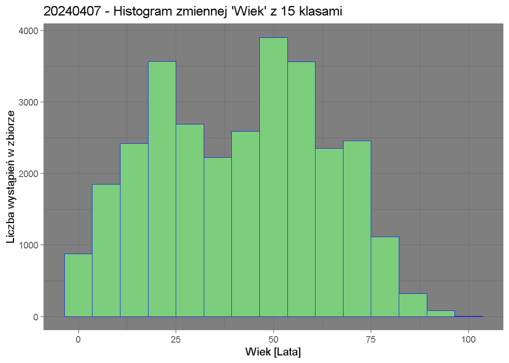

```r
okrojona_ramka_danych_budzety_2005 %>%
  ggplot() +
  geom_histogram(aes(x = Wiek),
                 bins = 15,
                 fill = "palegreen3", colour = "blue", linewidth = 0.1) +
  theme_dark() +
  labs(title = "20240407 - Histogram zmiennej 'Wiek' z 15 klasami",
       x = "Wiek [Lata]", y = "Liczba wystąpień w zbiorze")
```

#### Zestaw 3 - Podpunkt 2.10

Oryginalna treść podpunktu 2.10:

*“Narysować wykres pudełkowy (funkcja boxplot()) dla zmiennej totincGUS względem zmiennej sex i townsize (dwa osobne rysunki).”*

Rozwiązanie podpunktu:

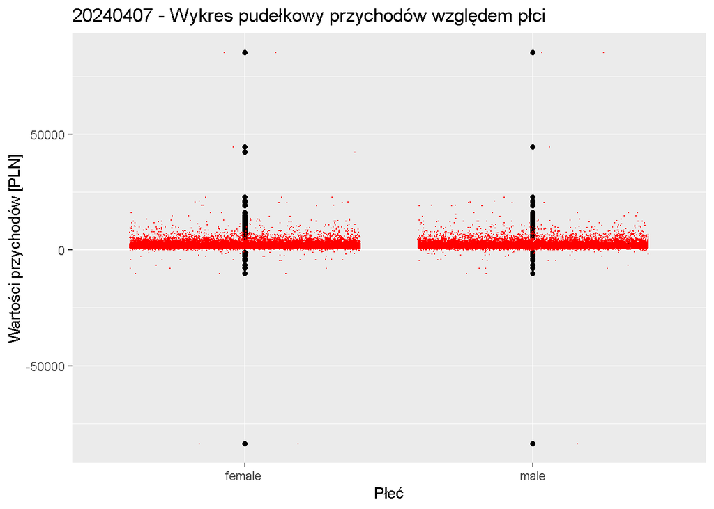

```r
# Wykres pudełkowy dla zmiennej: Przychody = f(Płeć)
tytul_wykresu <- paste("20240407 - Wykres pudełkowy przychodów względem płci")
okrojona_ramka_danych_budzety_2005 %>%
  select(Plec,Przychody) %>%
  ggplot(aes(x = Plec, y = Przychody)) +
  geom_boxplot(aes(y = Przychody), color = "black") +
  geom_jitter(height = 0.5, color = "red", size = 0.01) +
  labs(title = tytul_wykresu,
       x = "Płeć",
       y = "Wartości przychodów [PLN]")
```

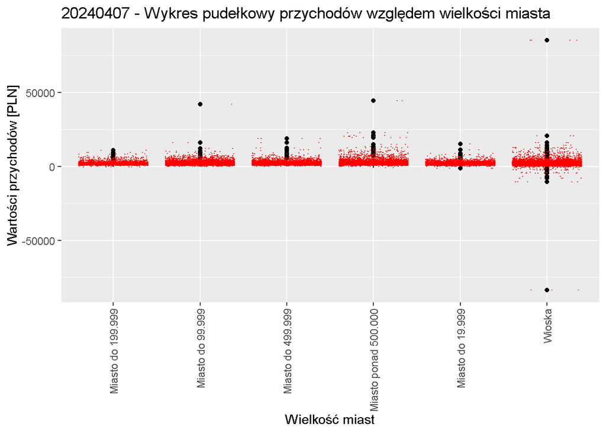

```r
# Wykres pudełkowy dla zmiennej: Przychody = f(Wielkość Miasta)
tytul_wykresu <- paste("20240407 - Wykres pudełkowy przychodów względem wielkości miasta")
okrojona_ramka_danych_budzety_2005 %>%
  select(Wielkosc_Miasta,Przychody) %>%
  ggplot(aes(x = Wielkosc_Miasta, y = Przychody)) +
  geom_boxplot(aes(y = Przychody), color = "black") +
  geom_jitter(height = 0.5, color = "red", size = 0.01) +
  labs(title = tytul_wykresu,
       x = "Wielkość miast",
       y = "Wartości przychodów [PLN]") +
  theme(axis.text.x = element_text(angle = 90, vjust = 0.5, hjust=1))
```

#### Zestaw 3 - Podpunkt 2.11

Oryginalna treść podpunktu 2.11:

*“Narysować wykres punktowy (funkcja plot()) wydatków zględem dochodów.”*

Rozwiązanie podpunktu:

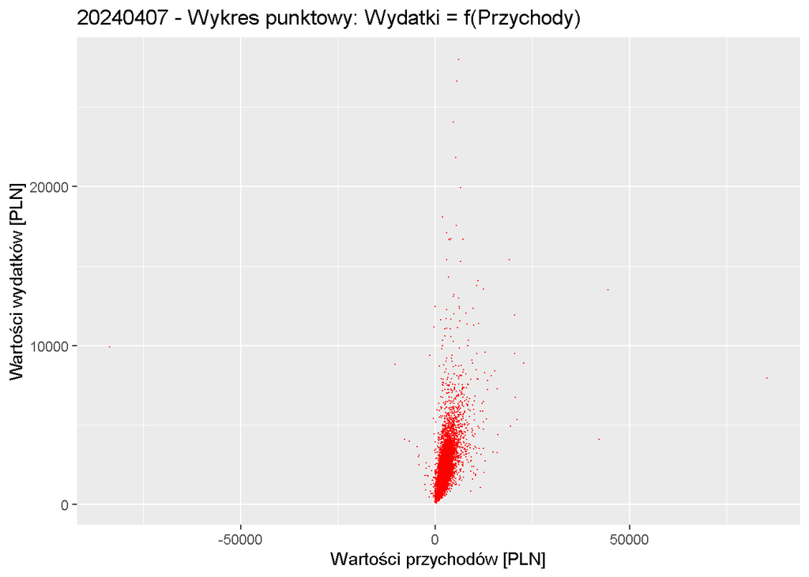

```r
tytul_wykresu <- paste("20240407 - Wykres punktowy: Wydatki = f(Przychody)")
okrojona_ramka_danych_budzety_2005 %>%
  select(Wydatki, Przychody) %>%
  ggplot(aes(y = Wydatki, x = Przychody)) +
  geom_point(color = "red", size = 0.1) +
  labs(title = tytul_wykresu,
       x = "Wartości przychodów [PLN]",
       y = "Wartości wydatków [PLN]")
```

#### Zestaw 3 - Podpunkt 2.12

Oryginalna treść podpunktu 2.12:

*“Pomyśl o kilku ciekawych pytaniach, na które możesz odpowiedzieć wykorzystując informację o typie posiadanej nieruchomości i jej wielkości. Zaprezentuj owe wyniki z wykorzystaniem poznanych funkcji.”*

Rozwiązanie podpunktu:

```r
# Krok 12.1 - Analiza oszczędnosci i zamiana dodatnich wartości oszczędności na wartość '1', a ujemnych wartości oszczędności na '0'. Innymi słowy, stosuję skalę porządkową dla danych 'Oszczędności' - zastępując wartości dodatnie wartością '1', a ujemne wartością '0'.
ramka_danych_oszczednosci_vs_plec <- ramka_danych_z_dodatkowymi_zmiennymi %>%
  select(Oszczednosci, Plec) %>%
  mutate(Oszczednosci = case_when(Oszczednosci > 0 ~ 1, .default = 0))
head(ramka_danych_oszczednosci_vs_plec,5)
```

```
##   Oszczednosci    Plec
## 1            0    male
## 2            0 female
## 3            0 female
## 4            0 female
## 5            0 female
```

```r
# Krok 12.2 - Test Chi-Square: sprawdzam czy istnieje zależność pomiędzy płcią, a oszczędnościami 'na plusie'... ;)
wartosci_testu <- chisq.test(as.numeric(ramka_danych_oszczednosci_vs_plec$Oszczednosci),
           as.character(ramka_danych_oszczednosci_vs_plec$Plec),
           simulate.p.value = TRUE)
p_value_testu <- round(as.numeric(wartosci_testu[3]),2)

# Krok 12.3 - Analiza wyników testu Chi-Square
poziom_istotnosci <- 0.05
if(p_value_testu > poziom_istotnosci)
{
  print(paste("Dla poziomu istotności",poziom_istotnosci,"oraz biorąc pod uwage wartość p-value testu statystycznego Chi-Kwadrat równą",p_value_testu,"stwierdzam, że brak jest podstaw do odrzucenia hipotezy zerowej. Innymi słowy, zdolność oszczędzania jest niezależna od płci. W tym przypadku, 'zdolność oszczędzania' definiowana jest jako dodatnie oszczędności."))
}else
{
  print(paste("Dla poziomu istotności",poziom_istotnosci,"oraz biorąc pod uwage wartość p-value testu statystycznego Chi-Kwadrat równą",p_value_testu,"stwierdzam, że są podstawy do odrzucenia hipotezy zerowej. Innymi słowy, zdolność oszczędzania jest zależna od płci. W tym przypadku, 'zdolność oszczędzania' definiowana jest jako dodatnie oszczędności."))
}
```

[output not shown]

## Literatura

[1] - https://www.rdocumentation.org/packages/utils/versions/3.6.2/topics/str

[2] - https://www.r-project.org/help.html

[3] - https://stat.ethz.ch/R-manual/R-devel/library/datasets/html/mtcars.html

[4] - https://stat.ethz.ch/R-manual/R-devel/library/datasets/html/Orange.html

[5] - https://dplyr.tidyverse.org/

[6] - https://search.r-project.org/CRAN/refmans/psych/html/describe.html

[7] - https://www.rdocumentation.org/packages/base/versions/3.6.2/topics/summary

[8] - https://www.geeksforgeeks.org/r-lists/

[9] - https://www.geeksforgeeks.org/if-else-if-statement-in-r/

[10] - https://www.geeksforgeeks.org/loops-in-r-for-while-repeat/

[11] - https://lubridate.tidyverse.org/

[12] - https://lubridate.tidyverse.org/reference/days_in_month.html